# Part II - Rider Demographics And Their Bike Share Patterns

## by Secil Carver

## Investigation Overview

> In this investigation, I wanted to look at the characteristics of bike share riders, the duration of rides, time of rides to understand who the bike share service user is and possible explanation of purpose for using this service. The main focus was on the demographics of the riders' (age, gender and user type), day/time the service was used, and the distance traveled.

## Dataset Overview

> There are a little over 180,000 bike share entries in the original dataset with 16 variables such as location coordinations, user birth year and gender. Less than 5% of the data had to be removed because of mostly null values, and a few hundred data point were removed due to unusual outlier behaviour.

## User Age

> There are some outliers in the members birth years such as an entry of 1878. The amount of outliers are insignificant in numbers, however they do skew the graphs. After removing outliers and keeping the data within 5 standard deviation from the mean, the age distribution of the data is concentrated between 25-45.

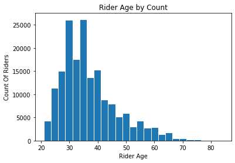

## Riders daily behaviour

> Riders daily behaviour as well as time of day behaviour reveals more information on what day of the week and what time of day is more popular with riders. Looking at both days of the month, and days of the week, weekends do not seem as popular with riders as weekdays are.

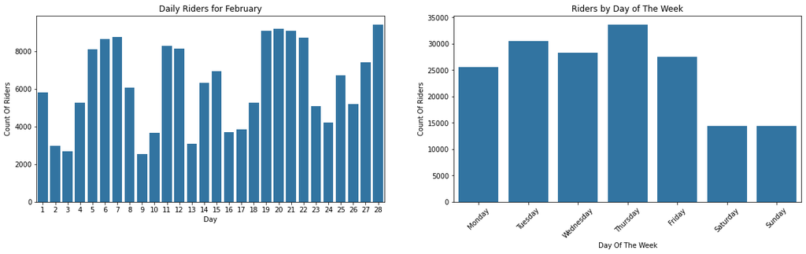

## Distance traveled by riders

> At first glance the distance traveled for bikers were clustered around 1 mile because of an outlier. Changing the x-axis limit to 5 miles we can get a closer look at the numbers. We now see the distance taveled by most bikers is less than 3 miles.

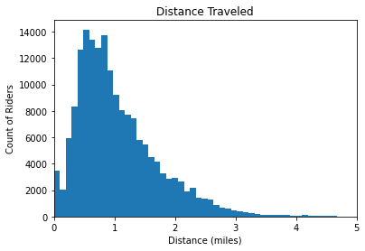

## Average ride duration and average distance traveled by riders

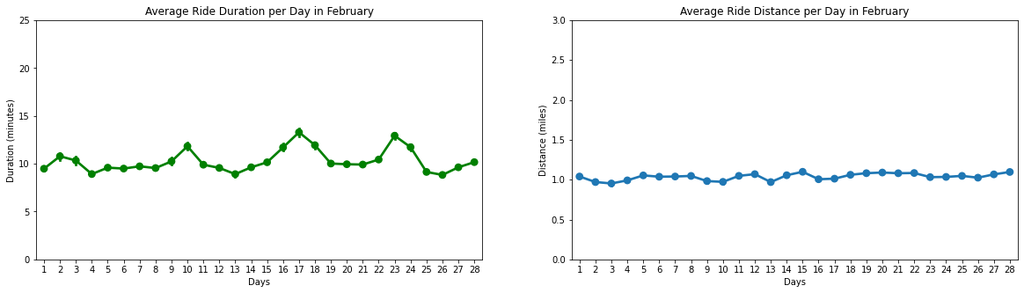

## Rider age and gender distribution

- Upon closer inspection we can conclude male customers who are between the age of 25-45 years of age are the biggest bike share users.

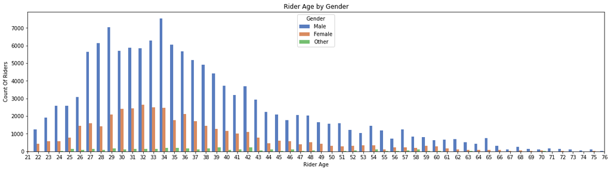

## Rider age and the distance traveled

- From the heat map I can clearly see the concentration of age is around 30, and distance traveled is mostly below 3 miles.

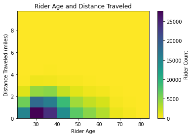

## User type, age, gender based on daily use

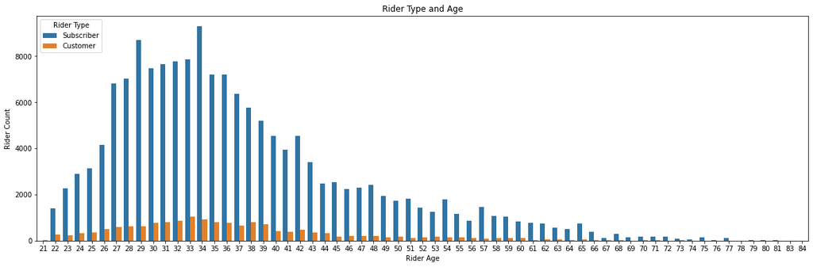

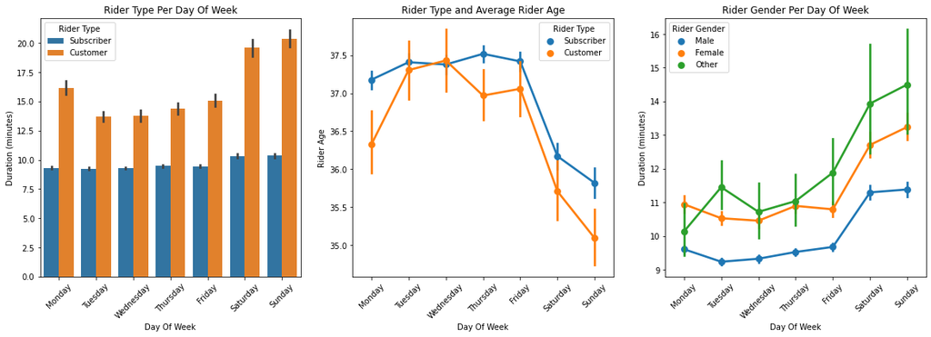